# Predicting Velocity with Force Plates: Can Lower Body Forces predict Velocity on the Mound?

Nick Katz

## Introduction

In the world of baseball performance training, lower-body mechanics and force output are often tracked in relation to throwing velocity. Pitchers rely heavily on their ability to generate force from the ground up, making lower-body strength and output a key factor in training and tracking of strength gain over time. This report explores data from counter-movement jump (CMJ) tests performed at Kinetic Performance Institute, a training facility I work at in California. This data is looking at one of 3 jumps we commonly use. In the future, I would like to look at all three jumps to gain a better understanding of velocity prediction. Metrics here are interpreted by coaches and programmed accordingly. Training practices reflect the weaknesses of athletes, and this model looks to build upon our already established system for programming.

## Data

These metrics were obtained from Hawkins Dynamics Force Plates. The specific numbers taken are the peak jump height and peak pitching velocity as of January 2025. All athletes test regularly (2-4 times per week), so further study could be done on average or time-based analytics. All metrics from the jump are included, totaling to 79 respective variables. Many of these metrics are similar in translation to performance; for example, peak and average are recorded for all power metrics. To combat this, the data set has been reduced to 14 predictor variables. These are chosen based on the physiological implication of the metric, accounting for time during the jump (phase) and global performance (general “output” variables categorizing the overall jump). There are still levels of multicollinearity, but this filtering reduces overlapping variables considerably.

- **Unweighting Phase**
  - *Unweighting phase (sec)*: total time of full dip in center-of-mass (COM)
- **Braking Phase**
  - *Relative Braking Net Impulse (N-s/kg)*: impulse of momentum change and energy storage accounting for weight
  - *Peak Relative Braking Force (N/kg)*: Peak capacity in energy transfer to prepare for verticalmovement
  - *Braking RFD (N-s)*: Rate of force development, important in any explosive movement
  - *Braking Average Braking Power (W)*: rate of work being done while moving down (negative, opposite of propulsive power)
- **Propulsive Phase**
  - *Average Propulsive Velocity (m/s)*: average speed while moving upwards in jump
  - *Propulsive Net Impulse (N-s)*: total force pushing off ground over time (momentum change)
  - *Average Relative Propulsive Force (N/kg)*: average force controlling for bodyweight
  - *Peak Relative Propulsive Force (N/kg)*: peak force controlling for bodyweight; peak change in momentum force
  - *Positive Net Impulse (N-s)*: excess force beyond resisting gravity applied over time
  - *Average Propulsive Power (W)*: rate of work being done across upward movement
- **Global Metrics**
  - *Jump Height (In)*
  - *Flight time (s)*: time in the air
  - *Landing Stiffness(N/m)*: good measure of ridgity of the landing phase, can be too high (stiff) or low (too loose)

```r
set.seed(208)


#got rid of athletes names and only included selected variables using select, made the variable names better formatted with clean_names()

force_plate_data <- forceplate_og_data %>%
  clean_names() %>%
  select(velocity, jh, braking_rfd, stiffness, flight_time, avg_propulsive_power, propulsive_net_impulse, positive_net_impulse, pr_propulsive_force, avg_r_propulsive_force,
         avg_propulsive_velo, avg_braking_power, pr_braking_force, braking_net_impulse, unweighting_phase, -name)
```

## Analysis/Methodology

```r
set.seed(208)

#All numeric variables

#No NA values
sum(is.na(force_plate_data))
```

```
## [1] 0
```

```r
#dataset for corr viz
importantvariables <- force_plate_data %>%
  select( avg_propulsive_power, propulsive_net_impulse, positive_net_impulse, pr_propulsive_force, avg_r_propulsive_force,  avg_propulsive_velo)


cor_mat <- cor(importantvariables)

cor_list <- as.data.frame(as.table(cor_mat)) %>%
  filter(Var1 != Var2) %>%
  arrange(desc(abs(Freq)))

kbl(cor_list)
```

| Var1 | Var2 | Freq |
| --- | --- | --- |
| positive_net_impulse | propulsive_net_impulse | 0.9682657 |
| propulsive_net_impulse | positive_net_impulse | 0.9682657 |
| propulsive_net_impulse | avg_propulsive_power | 0.9192774 |
| avg_propulsive_power | propulsive_net_impulse | 0.9192774 |
| positive_net_impulse | avg_propulsive_power | 0.8777645 |
| avg_propulsive_power | positive_net_impulse | 0.8777645 |
| avg_propulsive_velo | avg_propulsive_power | 0.6985856 |
| avg_propulsive_power | avg_propulsive_velo | 0.6985856 |
| avg_propulsive_velo | pr_propulsive_force | 0.6853446 |
| pr_propulsive_force | avg_propulsive_velo | 0.6853446 |
| avg_r_propulsive_force | pr_propulsive_force | 0.6206837 |
| pr_propulsive_force | avg_r_propulsive_force | 0.6206837 |
| avg_propulsive_velo | positive_net_impulse | 0.5943010 |
| positive_net_impulse | avg_propulsive_velo | 0.5943010 |
| avg_propulsive_velo | propulsive_net_impulse | 0.5832515 |
| propulsive_net_impulse | avg_propulsive_velo | 0.5832515 |
| avg_r_propulsive_force | avg_propulsive_power | 0.5344420 |
| avg_propulsive_power | avg_r_propulsive_force | 0.5344420 |
| pr_propulsive_force | avg_propulsive_power | 0.5126291 |
| avg_propulsive_power | pr_propulsive_force | 0.5126291 |
| avg_propulsive_velo | avg_r_propulsive_force | 0.4664070 |
| avg_r_propulsive_force | avg_propulsive_velo | 0.4664070 |
| pr_propulsive_force | positive_net_impulse | 0.3535028 |
| positive_net_impulse | pr_propulsive_force | 0.3535028 |
| pr_propulsive_force | propulsive_net_impulse | 0.3001280 |
| propulsive_net_impulse | pr_propulsive_force | 0.3001280 |
| avg_r_propulsive_force | propulsive_net_impulse | 0.2277869 |
| propulsive_net_impulse | avg_r_propulsive_force | 0.2277869 |
| avg_r_propulsive_force | positive_net_impulse | 0.1552400 |
| positive_net_impulse | avg_r_propulsive_force | 0.1552400 |

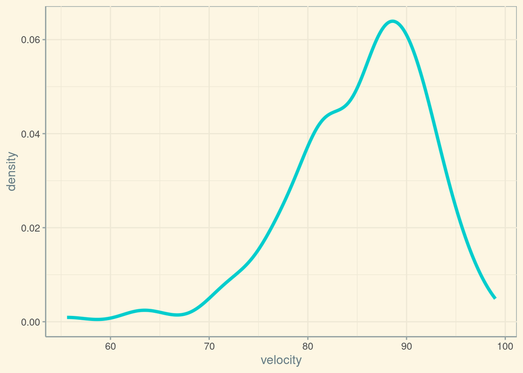

```r
#plot of response - slight negative skew, biased towards harder throwers with some younger athletes included.
ggplot(force_plate_data, aes(x = velocity)) +
  geom_density(color = "cyan3", size = 1.5) +
  theme_solarized()
```

```r
set.seed(208)
#splitting
data_split <- initial_split(data = force_plate_data, prop = 0.8)
fp_train <- training(data_split)
fp_test <- testing(data_split)

#blueprint
fp_recipe <- recipe(formula = velocity ~ ., data = fp_train)

#minimal FE for the blueprint to begin - no need to apply 2 blueprints, will work with this one
fp_blueprint <- fp_recipe %>%
  step_normalize(all_numeric_predictors())

#Prep and Bake
prepare <- prep(fp_blueprint, data = fp_train)

baked_train_fp <- bake(prepare, new_data = fp_train)

baked_test_fp <- bake(prepare, new_data = fp_test)


#CV grid
cv_specs <- trainControl(method = "repeatedcv",
                         number = 5,
                         repeats = 1)
```

### Linear Regression Model

```r
set.seed(208)

linear_model <- train(fp_blueprint,
                      data =  fp_train,
                      method = "lm",
                      trControl= cv_specs,
                      metric = "RMSE")
linear_model$results
```

```
##   intercept     RMSE Rsquared      MAE   RMSESD RsquaredSD  MAESD
## 1      TRUE 11.16264 0.408052 5.037456 14.73105  0.2646912 2.9417
```

```r
#RMSE: 11.16264
#RMSESD: 14.73105
```

### KNN Model

```r
#first attempted 1-51 by 10 - best tune was 11


#then attempted 1- 21 by 1 - best tune was 16
#k = 16
#RMSE = 5.10053
#RMSESD = 0.4312169

#kept 2nd grid, lower RMSE and RMSESD

set.seed(208)
k_grid_fp<- expand.grid(k = seq(1, 21, by = 1))

knn <- train(fp_blueprint,
                data = fp_train,
                method = "knn",
                trControl = cv_specs,
                tuneGrid = k_grid_fp,
                metric = "RMSE")

knn$results
```

```
##     k     RMSE  Rsquared      MAE    RMSESD RsquaredSD     MAESD
## 1   1 6.884234 0.1900054 5.568908 0.6022263 0.04784051 0.5551606
## 2   2 5.732635 0.3150775 4.638739 0.3722727 0.12745179 0.2769101
## 3   3 5.326331 0.3605736 4.179171 0.4701520 0.11206537 0.4188158
## 4   4 5.139083 0.3998648 4.068042 0.4985359 0.09061747 0.2169450
## 5   5 5.217645 0.3781625 4.138492 0.5102276 0.14379124 0.2684090
## 6   6 5.207492 0.3808560 4.113342 0.6089974 0.15573636 0.3639553
## 7   7 5.208831 0.3804847 4.119682 0.6471153 0.17021110 0.3728788
## 8   8 5.190784 0.3861626 4.110154 0.5955552 0.16048370 0.3501822
## 9   9 5.225605 0.3824577 4.135722 0.4756839 0.16558382 0.3151272
## 10 10 5.168235 0.3994575 4.081436 0.4360120 0.17553316 0.2810367
## 11 11 5.122560 0.4127782 4.066422 0.4652302 0.18273075 0.2623134
## 12 12 5.134401 0.4143314 4.078999 0.4789142 0.18104739 0.2364523
## 13 13 5.161547 0.4114985 4.122904 0.4240496 0.17564363 0.2157137
## 14 14 5.111389 0.4215145 4.055378 0.4271103 0.16757086 0.2047493
## 15 15 5.124441 0.4202460 4.064869 0.4204829 0.15623975 0.1634996
## 16 16 5.100530 0.4285431 4.044349 0.4312169 0.16411336 0.1903698
## 17 17 5.131003 0.4225525 4.069567 0.4004890 0.15943924 0.1459043
## 18 18 5.126769 0.4254304 4.054267 0.3977462 0.15868474 0.1461717
## 19 19 5.175990 0.4158242 4.109012 0.3700924 0.17129247 0.1727741
## 20 20 5.174244 0.4202455 4.095876 0.3714532 0.17881087 0.2214732
## 21 21 5.172528 0.4262988 4.096966 0.4521458 0.17366866 0.2242214
```

```r
knn$bestTune$k
```

```
## [1] 16
```

```r
min(knn$results$RMSE)
```

```
## [1] 5.10053
```

### Single Tree Model

```r
set.seed(208)
tree <- train(fp_blueprint,
                 data = fp_train,
                 method = "rpart",
                 trControl = cv_specs,
                 tuneLength = 20,
                 metric = "RMSE")


tree$results
```

```
##            cp     RMSE  Rsquared      MAE    RMSESD RsquaredSD     MAESD
## 1  0.00000000 5.463245 0.3850524 4.263806 0.8193584 0.18905040 0.6199108
## 2  0.01463668 5.379434 0.3930467 4.158078 0.8058045 0.18815055 0.6338292
## 3  0.02927335 5.464064 0.3700752 4.164527 0.5552723 0.13794594 0.5133145
## 4  0.04391003 5.679292 0.3159345 4.392491 0.7109449 0.16013028 0.5888367
## 5  0.05854671 5.717648 0.3031204 4.431929 0.7287677 0.17392514 0.5935408
## 6  0.07318338 5.879232 0.2680504 4.644648 0.5857624 0.17864231 0.5029477
## 7  0.08782006 5.896325 0.2676126 4.653181 0.5996877 0.17037641 0.4657666
## 8  0.10245673 6.013102 0.2325448 4.684797 0.6982032 0.12287954 0.4616837
## 9  0.11709341 6.091786 0.2131743 4.739879 0.6249345 0.10934751 0.4004736
## 10 0.13173009 5.996337 0.2156679 4.649537 0.5087245 0.10667643 0.2157602
## 11 0.14636676 5.959390 0.2243837 4.610052 0.5376219 0.09410764 0.2285013
## 12 0.16100344 6.028222 0.2034394 4.665010 0.4726585 0.08193058 0.2085772
## 13 0.17564012 6.028222 0.2034394 4.665010 0.4726585 0.08193058 0.2085772
## 14 0.19027679 6.028222 0.2034394 4.665010 0.4726585 0.08193058 0.2085772
## 15 0.20491347 6.028222 0.2034394 4.665010 0.4726585 0.08193058 0.2085772
## 16 0.21955014 6.028222 0.2034394 4.665010 0.4726585 0.08193058 0.2085772
## 17 0.23418682 6.028222 0.2034394 4.665010 0.4726585 0.08193058 0.2085772
## 18 0.24882350 6.028222 0.2034394 4.665010 0.4726585 0.08193058 0.2085772
## 19 0.26346017 6.028222 0.2034394 4.665010 0.4726585 0.08193058 0.2085772
## 20 0.27809685 6.403217 0.1644733 4.989789 0.9311167 0.06483268 0.5373338
```

```r
tree$bestTune$cp
```

```
## [1] 0.01463668
```

```r
#cp = 0.01463668
#RMSE = 5.379434
#RMSESD = 0.8058045
```